# Final Project Report

Team2

2022-12-14

# Final Project Report - Team 2

## 1. Introduction

Our project used car sales data scraped from popular online auto marketplace postings. The dataset contains information from each posting, including features such as the make, model, year, exterior color, drivetrain, etc. The project and the visualizations we created aim to analyze the general consumer preference in the whole United States, some preferences including mode, make, and color. Next, we also want to detect if each state has different tastes in fuel economy. Finally, users could check the general trends of how the mileage and year impact the price of a specific vehicle model. Then, compare with consumers’ gut feeling.

People who access our report and the shiny app could easily gain this information by selecting different tabs and buttons. In general, it could give users an idea of which car is the best choice for their future purchases.

#### Data Source

CarsForSale

https://www.kaggle.com/datasets/chancev/carsforsale?resource=download

#### Main Findings

1. The majority of individuals tend to choose darker hues, however in warmer regions like Texas, Arizona, and Florida, as opposed to colder regions like Illinois and New Jersey, more people are choosing lighter hues.
2. In line with common sense, the price decreased as the distance increased, and the longer the year, the less the price.
3. Colder regions with higher MPGs than California, Texas, and Florida include North Dakota, South Dakota, Wisconsin, and Iowa.

In the rest of our report, we will work through our data, detailed discussion of each tab, and our final conclusions.

## 2. Data Section

The data we chose was from Kaggle.com, and it was scraped from postings on a popular online auto marketplace. The dataset contains information from each posting, including features such as the make, model, year, exterior color, drivetrain, etc.

| Variable Name | Data Type | Description |
| --- | --- | --- |
| Year | Numeric | Model year |
| Make | Character | Brand of the car |
| Model | Character | Car model |
| Price | Character | Listing price |
| ConsumerRating | Numeric | Average consumer rating based on submitted consumer reviews |
| ConsumerReviews | Numeric | The number of reviews submitted for the car in the listing |
| State | Character | State of the seller’s location |
| ComfortRating | Numeric | How consumers rated the car’s comfort |
| InteriorDesignRating | Numeric | How consumers rated the car’s interior design |
| PerformanceRating | Numeric | How consumers rated the car’s performance |
| ValueForMoneyRating | Numeric | How consumers rated the car’s value for the price |
| ExteriorStylingRating | Numeric | How consumers rated the car’s exterior styling |
| ReliabilityRating | Numeric | How consumers rated the car’s reliability |
| ExteriorColor | Character | The car’s exterior color |
| InteriorColor | Character | The car’s interior color |
| MinMPG | Numeric | Bottom end miles per gallon |
| MaxMPG | Numeric | Top end miles per gallon |
| Mileage | Numeric | Number of miles on the car |
| FuelType | Character | Type of fuel that the car uses. (Gas, Electric, Hybrid, etc.) |
| DealType | Character | How good is the deal based on the average market price for the car in the listing? (Great, Good, Fair, NA) |

First, We filtered out instances that were not priced, converted the price to the numeric variable. Secondly, we removed all instances with a not applicable state variable, and subsetted the models with more than 50 cars to cars_Q3. After that, all exterior colors of the car as black, grey, granite, blue, gun, red, ebony, magnetic, ruby, graphite, and caviar were mutated as “Dark,” all silver, steel, white, pearl, and platinum were mutated as “Light” and all the rest colors as “others.” Next, the variable for fuel type was mutated and grouped into the right categories. Moreover, all variables about ratings have been converted from horizontal to vertical orientation.

## 3. Main Section

#### Most Popular car

Our team is interested in the sale of different makes of cars within the U.S. and all states. After our analysis of the data, we found out the top 3 most popular cars in the U.S. are BMW, Mercedes-Benz, and Toyota. However, there is a big difference in the popular cars in each state. For example, for the 5 states with the most s, Toyota is the most popular car brand in TX, and all three states of FL, CA and IL and IL has the same most popular make as Mercedes. Besides, BMW is the most popular make in New York. We assume the reason that BMW and Mercedes are two of the most popular cars could be that they are making high-quality cars and the fashion and status that comes with completeness. As for Toyota, the reason could be the feature of its high durability.

#### Price VS. Mileage

Our team is attempting to determine how the car’s mileage may impact the pricing of the same model car in this tab. Is it consistent with what we already know? We used the four variables from our dataset: mileage, price, model, and make. Any model quantity greater than 50 was selected in this tab to be plotted. Popular Japanese manufacturers like Toyota and Honda, family-friendly regional names like Ford and Jeep, and some luxury brands like BMW, Benz, and Cadillac are all represented among these vehicles.

In general, we discovered that the price dropped as the mileage rose, which aligned with our knowledge’s common sense. The cost of the car varies even with the same model and mileage. Numerous other things may impact this, we assume. We took into account various factors, including the cost of goods in various areas, the vehicle’s condition, available amenities, and pricing points.

In contrast, certain luxury brands don’t maintain their value. The price difference might be more than $20,000, like the Benz C300. As the BMW X5, the price difference might be above $30,000. That is a sizable automobile discount. Given that the C300 and Pilot have comparable beginning prices for new cars, starting at roughly $40,000, there is a clear difference in the preservation rate.

Aside from that, our initial assumption was that the starting price might affect the price’s loss; the greater the starting price, the higher the loss might be. In our dataset, we didn’t notice many differences, though. Similar trends are seen in several models from the same brand. We were surprised that the largest price difference for several models is about $15,000.We don’t know what caused that pattern.

#### Price VS. Year

In this tab, our team aims to determine how the car’s year may impact the pricing of the same model car. Is it consistent with our common knowledge? We used the four variables from our dataset: year, price, model, and make. Any model quantity greater than 50 was selected in this tab to be plotted. The selected model and make are similar to the previous tab.

The longer the year, the lower the price, as seen by the total price trend, which is compatible with people’s common sense. We also observed that the prices of the comparatively newer vehicles had been properly preserved. This discovery could be used for both low-cost and high-end brands. Comparing the prices of the Toyota RAV4 and the Benz GLC 300, both produced in the past three years; they have remained at around $35,000 and $45,000, respectively.

Additionally, we noticed that prices fluctuate even for vehicles built in the same year. We suppose some causes are the same as those covered in the causes tab above. However, we neglected that this dataset lacks information on the exact date a given car was sold. An automobile manufactured in 2018 and sold in 2018 or 2020 would cost different amounts. To answer this question, we might require additional information.

#### Color Distribution VS. State

Color selection confuses many people when they buy a car, should they go for darker colors or should they go with lighter white colors? This confusion arises depending on the state’s climate, as we all know that darker colors observe heat compared to light colors. Another factor is the willingness to wash/clean the car, as lighter colors require more cleaning compared to dark colors.

Out of this curiosity, we have tried to show the count for each color for a given state. But the problem was that each manufacturer would have a different color naming scheme and we could not group them. To overcome this issue we have grouped all the colors which have”Black,Grey,Granite,Blue,Gun,Red,Ebony,Magnetic,Ruby,Graphite,Caviar” in their exterior color name and marked them as dark. In the same way we have also grouped the colors “Silver,Steel,White,Pearl,Platinum” as light color and the remaining colors which are not part of these are grouped as others.

We know that this is not a very accurate way to separate the colors, but this gives us a good estimate of people’s choices while purchasing a vehicle. Via this result, we found that most people generally go with the darker colors but in warmer places like Texas, Arizona, and Florida, the number of lighter colors increases in contrast to the colder places like Illinois and New Jersey.

#### MPG VS. State

The team wanted to show the state-wise MPG. In our data, we had min MPG(city MPG) and Max MPG(Highway MPG). Also, we needed to clean our data as we had different fuel types(this was done in the data cleaning step). We grouped our data state, fuel type and calculated the average Min and Max MPG. Once we had this data, we needed to display that in an geo-spatial graph.

The major challenge was here to join our data set with the geo data of default US map. Our data set only had the 2 letter abbreviation of the states, which cannot be joined with the ggplot’s map data. So we decided to import the us map package(it’s a package with state names and their population). Then we joined our data set to this map and plotted a geo-spatial graph.

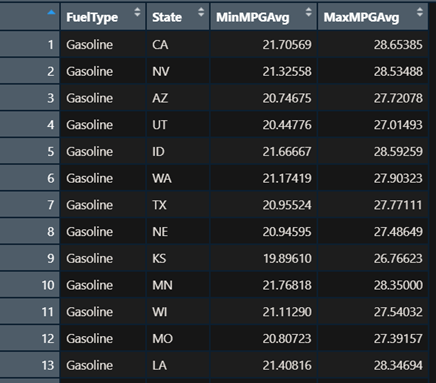

Min and Max MPG

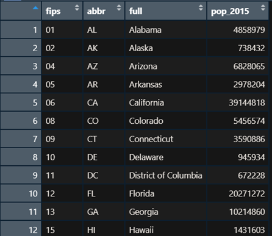

Usmap Data

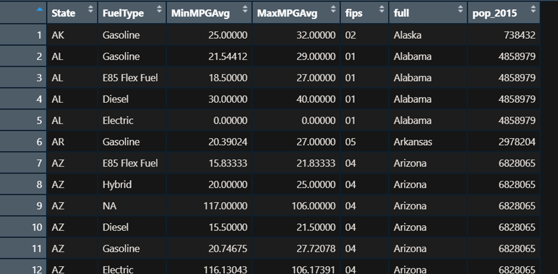

Joined Dataset

#### Make Rating VS. Year

People also want to check the reviews of make before doing a purchase. So in this graph, we tried to provide the various ratings (ComfortRating, InteriorDesignRating, PerformanceRating, ValueForMoneyRating, ExteriorStylingRating, ReliabilityRating) of the Make by year in the form of a box plot.

The major challenge we faced in this boxplot was the data we had was in a wide format, and we could not plot a boxplot from that. So we had to transpose that data from wide to long format and then plot the graph by grouping the year and making.

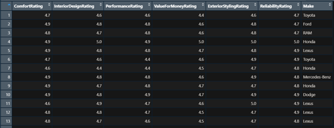

Data Wide Format

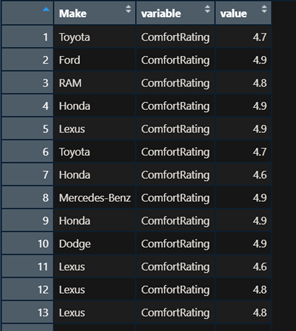

Data Long Format

#### Deal Type VS. State

In this tab, we plan to see the customer’s assessment of the dealers’ service level. And if different states have some obvious differences. We used two variables, deal type and state in this tab.

We discovered that most states are similar to one another’s three stages of evaluation’s amount. Most of the reviews are good, and about 30% are great. The remaining reviews are fair. Nevertheless, several exceptions have been found. Take LA, for example; there is about as many fair as great, and 10% of people are fair. We reasoned that the few sample sizes were probably to blame. We noticed that the number of the good and the great is nearly equal in VA. It appears that a big loss was turned into a good. This may show that Virginia’s service level needs to be raised going forward or that residents there have higher standards for the quality of services they receive.

We generally consider that customers are more inclined to provide a neutral grade. That is the root cause of the high number of good in this section.

## 4. Conclusions

In the future, the project may be improved with more car sales data being provided. Look at the dataset we got right now; most data point are generated from the West or East coast, which make us difficult to find more accurate trends and customers’ purchase behavior based on this data. Secondly, our team could create a new variable called “Rate of Value Preservation” to measure accurately how well a model or a brand preserve its value. To implement this step, we may need to import the average purchasing price of a certain type of vehicle. And create a model to put both mileage and year into consideration. Finally, the ideal situation is that we could know our customers’ preferences and demand for information and graphs. Then, we can develop our Shiny App according to their demand to better support their future decision-making process.